# Analyze the ToothGrowth data in the R datasets package

ِAbdallah Mohammed

2024-10-04

# summary of the data:

The response is the length of odontoblasts (cells responsible for tooth growth) in 60 guinea pigs. Each animal received one of three dose levels of vitamin C (0.5, 1, and 2 mg/day) by one of two delivery methods, orange juice or ascorbic acid (a form of vitamin C and coded as VC).

## Form:

**`A data frame with 60 observations on 3 variables.`**  
1. len -> numeric Tooth length  
2. supp -> factor Supplement type (VC or OJ).  
3. dose -> numeric Dose in milligrams/day

## Source:

C. I. Bliss (1952). The Statistics of Bioassay. Academic Press.

## References:

- McNeil, D. R. (1977). Interactive Data Analysis. New York: Wiley.
- Crampton, E. W. (1947). The growth of the odontoblast of the incisor teeth as a criterion of vitamin C intake of the guinea pig. The Journal of Nutrition, 33(5), 491–504. doi:10.1093/jn/33.5.491.

# Basic Exploratory Data Analysis:

```r
# Load the dataset
library(dplyr)
data("ToothGrowth")

# Convert dose to factor
ToothGrowth$dose <- factor(ToothGrowth$dose)

# Basic structure and summary of the data
str(ToothGrowth)
```

```
## 'data.frame':    60 obs. of  3 variables:
##  $ len : num  4.2 11.5 7.3 5.8 6.4 10 11.2 11.2 5.2 7 ...
##  $ supp: Factor w/ 2 levels "OJ","VC": 2 2 2 2 2 2 2 2 2 2 ...
##  $ dose: Factor w/ 3 levels "0.5","1","2": 1 1 1 1 1 1 1 1 1 1 ...
```

```r
summary(ToothGrowth)
```

```
##       len        supp     dose
##  Min.   : 4.20   OJ:30   0.5:20
##  1st Qu.:13.07   VC:30   1  :20
##  Median :19.25           2  :20
##  Mean   :18.81
##  3rd Qu.:25.27
##  Max.   :33.90
```

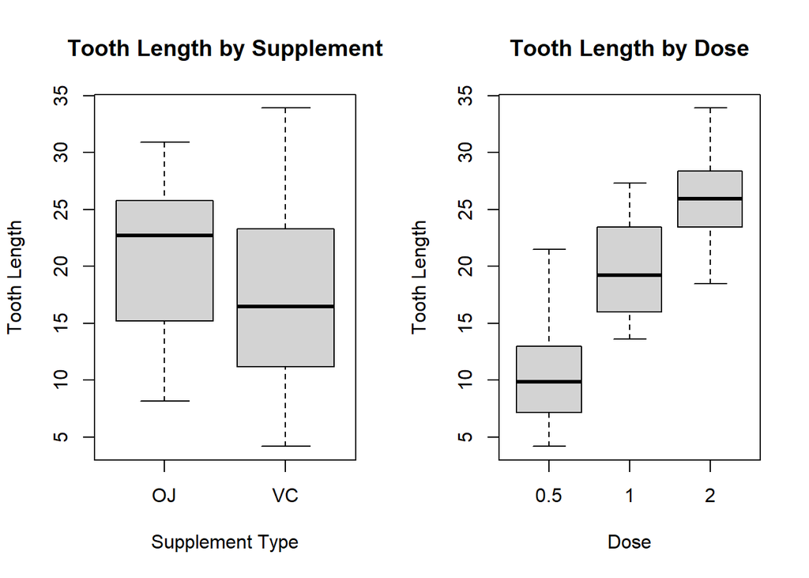

```r
# Plotting the relationship between length and the two factors (supp and dose)
par(mfrow=c(1,2))
with(ToothGrowth, plot(len ~ supp, main = "Tooth Length by Supplement",
                       ylab = "Tooth Length", xlab = "Supplement Type"))
with(ToothGrowth, plot(len ~ dose, main = "Tooth Length by Dose",
                       ylab = "Tooth Length", xlab = "Dose"))
```

# Hypotheses

## Comparison of Supplement Type (VC vs OJ):

- Null Hypothesis (H0): There is no difference in tooth length between the VC supplement and orange juice (OJ).
- Alternative Hypothesis (H1): There is a difference in tooth length between the VC supplement and orange juice (OJ).

## Comparison of Doses:

- Null Hypothesis (H0): There is no difference in tooth length among the different doses of Vitamin C (0.5, 1, and 2 mg/day).
- Alternative Hypothesis (H1): There is a difference in tooth length among the different doses of Vitamin C

# Hypothesis Tests and Confidence Intervals:

In this section, we will use t-tests to compare the tooth length by supplement type (supp) and by dose (dose). The t-tests will help us determine if there are statistically significant differences between groups.

## Comparison by Supplement (VC vs OJ):

```r
# T-test to compare tooth length by supplement
p_value_supp <- with(ToothGrowth, t.test(len ~ supp, alternative = "greater"))$p.value
p_value_supp
```

```
## [1] 0.03031725
```

p-value: 0.0303

## Comparison by Dose:

For the dose comparison, we’ll perform pairwise t-tests between the three dose levels (0.5, 1, and 2 mg/day) to see if higher doses result in more tooth growth.

```r
# Pairwise t-tests for dose levels
p_value_dose_1_0.5 <- t.test(len ~ dose, data = ToothGrowth %>% filter(dose %in% c(0.5, 1)),
                             alternative = "less")$p.value
p_value_dose_2_0.5 <- t.test(len ~ dose, data = ToothGrowth %>% filter(dose %in% c(0.5, 2)),
                             alternative = "less")$p.value
p_value_dose_2_1 <- t.test(len ~ dose, data = ToothGrowth %>% filter(dose %in% c(1, 2)),
                           alternative = "less")$p.value

p_value_dose_1_0.5
```

```
## [1] 6.341504e-08
```

```r
p_value_dose_2_0.5
```

```
## [1] 2.198762e-14
```

```r
p_value_dose_2_1
```

```
## [1] 9.532148e-06
```

# Conclusions and Assumptions:

## Conclusions:

### Comparison of Doses:

#### Dose 1 vs Dose 0.5:

- p-value: 6.34e-08
- Conclusion: The p-value is much lower than 0.05, indicating a statistically significant difference between the two doses. We conclude that Dose 1 leads to a statistically significant increase in tooth length compared to Dose 0.5.

#### Dose 2 vs Dose 0.5:

- p-value: 2.20e-14
- Conclusion: The p-value suggests a strong significant difference between the two doses. We conclude that Dose 2 results in a substantial statistically significant increase in tooth length compared to Dose 0.5.

#### Dose 2 vs Dose 1:

- p-value: 9.53e-06
- Conclusion: Again, the p-value is less than 0.05, indicating a statistically significant difference between the two doses. We conclude that Dose 2 leads to a statistically significant increase in tooth length compared to Dose 1.

### Summary:

The results indicate that the use of Vitamin C (either from the VC supplement or orange juice) and higher doses of it positively affect tooth growth in guinea pigs. Overall, we can say that higher doses of Vitamin C significantly enhance tooth growth